# Assignment 2: SQL & R

Jordan Tapke

9/3/2020

### Introduction

The Assignment requirements included:

1. Survey friends on 6 movie titles and ask them to rank the titles from 1 to 5
2. Import the collected data into R to store in a relational database
3. Import the data from database into R for analysis

### Survey

To collect the data on movies I created a survey using [Google forms.](https://forms.gle/spNTAcBCkJv5zKFN8)

Survey results are available on [Github](https://github.com/jtapke/School-Projects/blob/master/MovieSurveyResponses.csv)

### Store Data in MySQL Database

I took these steps to upload the data into a MySQL database in Google Cloud:

1. Create connection to the database without saving password.
2. Create a table in the database for the data to be inserted in.
3. Import the data into a dataframe from the CSV file and amend the column names.
4. Write the dataframe to the database.

```r
library(RMariaDB)

#Create Connection to database without showing password
con <- dbConnect(RMariaDB::MariaDB(),
                 dbname = 'movie_preferences',
                 user = 'jtapke',
                 password = rstudioapi::askForPassword("Database password"),
                 host = '34.75.89.1')
```

OPTION 1: CREATE TABLE IN DATABASE

```r
#Create Table in database
dbSendQuery(con, "
CREATE TABLE IF NOT EXISTS movie_preferences.moviesurvey (
survey_id INT,
time CHAR(100),
parasite INT,
joker INT,
avengers_end_game INT,
crazy_rich_asians INT,
black_panther INT,
deadpool INT
);
")
```

OPTION 2: CREATE NORMALIZED SET OF TABLES IN DATABASE

```r
#Create Tables in database
dbSendQuery(con, "
CREATE TABLE IF NOT EXISTS movie_preferences.surveyinfo (
survey_id INT NOT NULL AUTO_INCREMENT,
time CHAR(100),
PRIMARY KEY (survey_id)
);
")
dbSendQuery(con, "
CREATE TABLE IF NOT EXISTS movie_preferences.movies (
movie_id INT NOT NULL AUTO_INCREMENT,
movie CHAR(100),
PRIMARY KEY (movie_id)
);
")
dbSendQuery(con, "
CREATE TABLE IF NOT EXISTS movie_preferences.ratings (
survey_id INT,
movie_id INT,
rating INT,
FOREIGN KEY (survey_id) REFERENCES surveyinfo(survey_id),
FOREIGN KEY (movie_id) REFERENCES movies(movie_id)
);
")
#Create dataframe from csv file
moviesurvey <- read.csv(url("https://raw.githubusercontent.com/jtapke/School-Projects/master/MovieSurveyResponses.csv"))

#Change column names to match those in the database
colnames(moviesurvey) <- c("survey_id","time", "parasite","joker","avengers_end_game","crazy_rich_asians","black_panther","deadpool")

head(moviesurvey)
```

```
##   survey_id                      time parasite joker avengers_end_game
## 1         1 2020/09/01 1:22:26 PM AST        5    NA                NA
## 2         2 2020/09/01 1:23:02 PM AST       NA     3                 5
## 3         3 2020/09/01 1:26:18 PM AST        5    NA                NA
## 4         4 2020/09/01 1:30:07 PM AST       NA    NA                NA
## 5         5 2020/09/01 1:30:15 PM AST        4     5                NA
## 6         6 2020/09/01 1:30:54 PM AST        4     2                 1
##   crazy_rich_asians black_panther deadpool
## 1                 4             5        4
## 2                 5             5        4
## 3                NA            NA       NA
## 4                 5            NA       NA
## 5                 4            NA        5
## 6                 4             1        1
```

```r
#Write the dataframe to the database table created
dbWriteTable(con, name = "moviesurvey", value = moviesurvey, append = TRUE)
```

### Importing and Preparing Data

I took these steps to import and prepare the data for analysis:

1. Import table from database into dataframe.
2. Tidy up the data so there are now “movie” and “rating” columns while dropping the null values.

```r
#Import table from database into dataframe
library(tidyr)
movieratings <- dbGetQuery(con, "SELECT * FROM moviesurvey")

long_movieratings <- movieratings%>% pivot_longer(3:8, names_to = 'movie', values_to = 'rating', values_drop_na = TRUE)
long_movieratings
```

```
## # A tibble: 352 x 4
##    survey_id time                      movie             rating
##        <int> <chr>                     <chr>              <int>
##  1         1 2020/09/01 1:22:26 PM AST parasite               5
##  2         1 2020/09/01 1:22:26 PM AST crazy_rich_asians      4
##  3         1 2020/09/01 1:22:26 PM AST black_panther          5
##  4         1 2020/09/01 1:22:26 PM AST deadpool               4
##  5         2 2020/09/01 1:23:02 PM AST joker                  3
##  6         2 2020/09/01 1:23:02 PM AST avengers_end_game      5
##  7         2 2020/09/01 1:23:02 PM AST crazy_rich_asians      5
##  8         2 2020/09/01 1:23:02 PM AST black_panther          5
##  9         2 2020/09/01 1:23:02 PM AST deadpool               4
## 10         3 2020/09/01 1:26:18 PM AST parasite               5
## # ... with 342 more rows
```

### Analysis

Below allows us to visualize the data in a grouped bar plot.

```r
library(tidyverse)
```

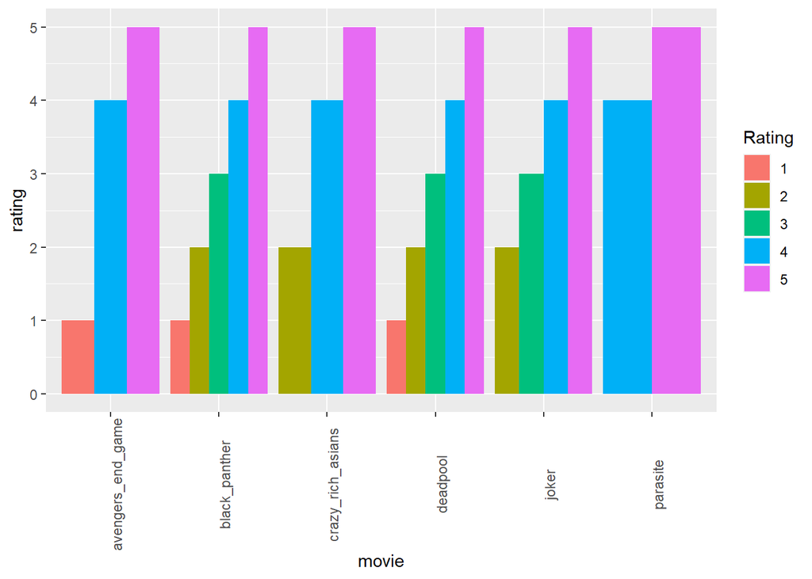

```r
ggplot(long_movieratings, aes(movie, rating), group = rating) +
  geom_bar(aes(fill=factor(rating)), position = "dodge", stat = "identity", width=.9)+
  theme(axis.text.x = element_text(angle = 90))+
  scale_fill_discrete(name = "Rating")
```

### Recomending Movies

One way we can use this data to recommend movie titles to the survey participants is to add a genre column to the movie table in the database. We can then match people who highly rated one genre to movie titles of the same genre. For Example: Survey participate #1 rated “Black Panther” as 5. Since this is a part of the superhero genre, we can recommend them another superhero movie that they have not watched such as “Joker.”

### Conclusion

After completing this project I would recommend using scenario #2: creating a normalized database. This allows for more information to be added, such as a genre column, to the database without being redundant.